# Gewichtung

Jan-Philipp Kolb

11 April 2016

## Eigenschaften von Gewichten

- Ein Survey-Gewicht ist ein Wert, der jeweils einer Beobachtung zugeordnet ist.
- Oft werden Gewichte auf die Anzahl der Fälle oder die Populationsgröße normiert.
- Ein Gewicht w kann kleiner , gleich oder größer als 1 sein.
- Ein Design-Gewicht ist bei der Schätzung proportional zum relativen Beitrag eines Befragten.
- Es ist proportional zum Inversen der Inklusionswahrscheinlichkeit.
- Die Größe einer speziellen Gruppe wird durch die Summe ihrer Gewichte geschätzt.

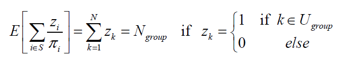

Formel 1

## Verschiedene Arten von Gewichten

Designgewicht

- um die Stichprobenziehung mit ungleichen Wahrscheinlichkeiten zu kompensieren (z.B. stratifizierte Stichproben mit einer disproportionalen Allokation)

Anpassungsgewichte

- um schlechte Stichproben anzupassen
- um Nonresponse zu Kompensieren

Gesamtgewicht

Gesamtgewicht = Design-Gewicht * Anpassungsgewicht

## Was sind Design-Gewichte

- Stichprobenziehung - also keine Vollerhebung
- ungleiche Wahrscheinlichkeiten - bspw. durch Schichtung und Klumpung

## Stratified sampling with disproportional allocation

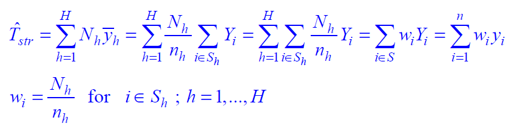

Stratfied Sampling

Horvitz-Thompson estimator is identical to the usual stratified estimator

## [Beispiel Lohr](http://www.stat.purdue.edu/~jennings/stat522/datasets/index.html)

| state | acres92 | acres87 | region | weight |
| --- | --- | --- | --- | --- |
| NE | 297326 | 332862 | NC | 10.23301 |
| IN | 124694 | 131481 | NC | 10.23301 |
| OH | 246938 | 263457 | NC | 10.23301 |
| MI | 206781 | 190251 | NC | 10.23301 |
| WI | 78772 | 85201 | NC | 10.23301 |
| MN | 210897 | 229537 | NC | 10.23301 |

Example Lohr agstrat.dat Strata: North Central, Northeast, South, West

## [Alle Beispiele von Lohr](https://r-forge.r-project.org/scm/viewvc.php/*checkout*/pkg/inst/doc/SDaA_using_survey.Rnw?revision=24&root=sda&pathrev=24)

|  | acres87 |
| --- | --- |
| acres92 | 0.9865652 |

|  | acres87 |
| --- | --- |
| acres92 | 3.66e-05 |

## Horvitz Thompson

The Horvitz-Thompson estimator for the total T_y is defined by

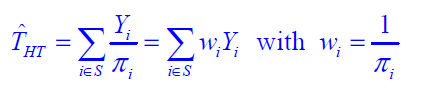

Horvitz Thompson

It is unbiased if all inclusion probabilities are positive. The variance of the Horvitz-Thompson estimator is given by:

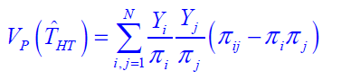

Variance HT

If all inclusion probabilities of second order pi_ij are positive we have:

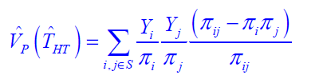

VarianceHT2

## Cell Weights

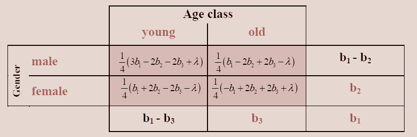

Cell Weights

The iterative proportional fitting algorithm (IPF) is an iterative algorithm for estimating cell values of a contingency table such that the marginal totals remain fixed and the estimated table decomposes into an outer product.

Deming and Stephan(1940)

## Nonresponse

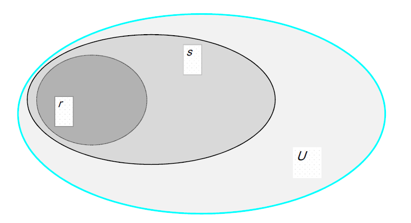

Non Response

## Nonresponse

Sometimes, answers for some units of the selected sample are either totally or partly missing. This is referred to as nonresponse. Sources for unit non-response can be not-athomes, refusals, unable to answer or not found. If a respondent answers some but not all the items, these missing are referred to as item non-response. Non-response is a very serious problem and the treatment of which requires modeling assumptions. Therefore, it may be easier to deal with non-response in the framework of model-based inference. Usually, weighting procedures are applied for treating unit non-response and imputation methods for item non-response. Calibration estimators are used very often nowadays to get a grip on the non-response problem.

## Calibration Estimator (GREG)